# V3_CustomerChurn

```python
%matplotlib inline
import pandas as pd

# Dataset
path = "D:/Datasets1/GithubProjects/Project3_PredictiveCustomerChurn/WA_Fn-UseC_-Telco-Customer-Churn.csv"
df = pd.read_csv(path)
df.head()
```

|  | customerID | gender | SeniorCitizen | Partner | Dependents | tenure | PhoneService | MultipleLines | InternetService | OnlineSecurity | ... | DeviceProtection | TechSupport | StreamingTV | StreamingMovies | Contract | PaperlessBilling | PaymentMethod | MonthlyCharges | TotalCharges | Churn |
| --- | --- | --- | --- | --- | --- | --- | --- | --- | --- | --- | --- | --- | --- | --- | --- | --- | --- | --- | --- | --- | --- |
| 0 | 7590-VHVEG | Female | 0 | Yes | No | 1 | No | No phone service | DSL | No | ... | No | No | No | No | Month-to-month | Yes | Electronic check | 29.85 | 29.85 | No |
| 1 | 5575-GNVDE | Male | 0 | No | No | 34 | Yes | No | DSL | Yes | ... | Yes | No | No | No | One year | No | Mailed check | 56.95 | 1889.5 | No |
| 2 | 3668-QPYBK | Male | 0 | No | No | 2 | Yes | No | DSL | Yes | ... | No | No | No | No | Month-to-month | Yes | Mailed check | 53.85 | 108.15 | Yes |
| 3 | 7795-CFOCW | Male | 0 | No | No | 45 | No | No phone service | DSL | Yes | ... | Yes | Yes | No | No | One year | No | Bank transfer (automatic) | 42.30 | 1840.75 | No |
| 4 | 9237-HQITU | Female | 0 | No | No | 2 | Yes | No | Fiber optic | No | ... | No | No | No | No | Month-to-month | Yes | Electronic check | 70.70 | 151.65 | Yes |

5 rows × 21 columns

```python
# Basic info
print("Dataset info:\n",df.info())
```

```
<class 'pandas.core.frame.DataFrame'>
RangeIndex: 7043 entries, 0 to 7042
Data columns (total 21 columns):
 #   Column            Non-Null Count  Dtype
---  ------            --------------  -----
 0   customerID        7043 non-null   object
 1   gender            7043 non-null   object
 2   SeniorCitizen     7043 non-null   int64
 3   Partner           7043 non-null   object
 4   Dependents        7043 non-null   object
 5   tenure            7043 non-null   int64
 6   PhoneService      7043 non-null   object
 7   MultipleLines     7043 non-null   object
 8   InternetService   7043 non-null   object
 9   OnlineSecurity    7043 non-null   object
 10  OnlineBackup      7043 non-null   object
 11  DeviceProtection  7043 non-null   object
 12  TechSupport       7043 non-null   object
 13  StreamingTV       7043 non-null   object
 14  StreamingMovies   7043 non-null   object
 15  Contract          7043 non-null   object
 16  PaperlessBilling  7043 non-null   object
 17  PaymentMethod     7043 non-null   object
 18  MonthlyCharges    7043 non-null   float64
 19  TotalCharges      7043 non-null   object
 20  Churn             7043 non-null   object
dtypes: float64(1), int64(2), object(18)
memory usage: 1.1+ MB
Dataset info:
 None
```

## Data Cleaning

```python
# Standardize column names
df.columns = [col.strip().lower().replace(" ", "_") for col in df.columns]

# Removing customerID and gender columns (irrelevent)
df.drop('customerid', axis=1, inplace=True)
df.drop('gender', axis=1, inplace=True)

# Converting "TotalCharges" to float
df['totalcharges'] = pd.to_numeric(df['totalcharges'], errors='coerce')
df.dropna(subset=['totalcharges'], inplace=True)  # Dropping rows with NaN

# Check for missing values
print("\nMissing values:")
print(df.isnull().sum())
```

```
Missing values:
seniorcitizen       0
partner             0
dependents          0
tenure              0
phoneservice        0
multiplelines       0
internetservice     0
onlinesecurity      0
onlinebackup        0
deviceprotection    0
techsupport         0
streamingtv         0
streamingmovies     0
contract            0
paperlessbilling    0
paymentmethod       0
monthlycharges      0
totalcharges        0
churn               0
dtype: int64
```

```python
# converting non-binary categorical variables to binary categorical variables (to avoid redundantness)

# Simplifying columns to Yes/No strings
svc_cols = ['onlinesecurity', 'onlinebackup', 'deviceprotection','techsupport', 'streamingtv', 'streamingmovies']

for col in svc_cols:
    df[col] = df[col].replace('No internet service', 'No')

# Simplifying multiplelines to just 'Yes'/'No'
df['multiplelines'] = df['multiplelines'].replace('No phone service', 'No')

df['seniorcitizen'] = df['seniorcitizen'].map({ 0:'No', 1:'Yes'})
```

## Exploratory Data Analysis (EDA)

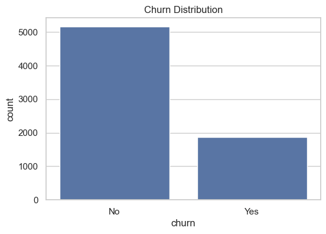

```python
import matplotlib.pyplot as plt
import seaborn as sns

# Set style
sns.set(style="whitegrid")

# Target Variable Distribution
plt.figure(figsize=(6,4))
sns.countplot(x='churn', data=df)
plt.title('Churn Distribution')
plt.show()
```

#### Churn Distribution

**Observation:** Significant class imbalance (many more "No Churn" than "Churn" cases).

**Insight:**

- We may need techniques like SMOTE (oversampling) or class weights in modeling to handle imbalance.
- Metric choice matters—prioritize recall or F1-score over accuracy.

```python
# Numerical Features Analysis
from scipy.stats import pointbiserialr

# Encoding target variable
df['churn'] = df['churn'].map({'Yes': 1, 'No': 0})
df['churn'] = df['churn'].astype(int)

numerical = ['tenure', 'monthlycharges', 'totalcharges']

print(df[numerical].describe())

for col in numerical :
    r, p = pointbiserialr(df[col], df['churn'])
    print(f"{col}: r={r:.2f}, p={p:.3f}")
```

```
            tenure  monthlycharges  totalcharges
count  7032.000000     7032.000000   7032.000000
mean     32.421786       64.798208   2283.300441
std      24.545260       30.085974   2266.771362
min       1.000000       18.250000     18.800000
25%       9.000000       35.587500    401.450000
50%      29.000000       70.350000   1397.475000
75%      55.000000       89.862500   3794.737500
max      72.000000      118.750000   8684.800000
tenure: r=-0.35, p=0.000
monthlycharges: r=0.19, p=0.000
totalcharges: r=-0.20, p=0.000
```

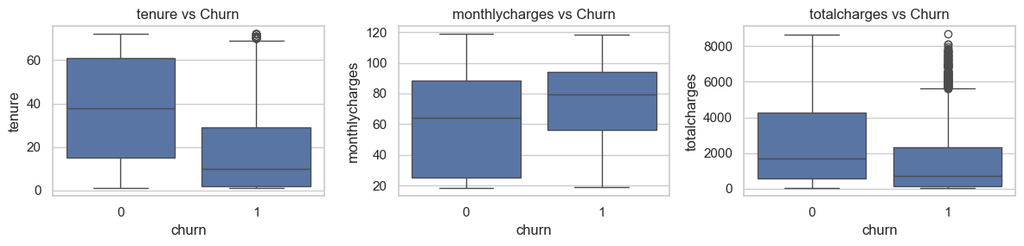

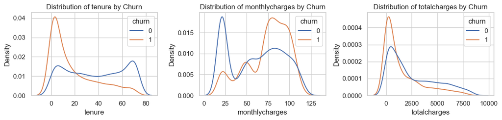

```python
# Visualizing numerical features vs churn with boxplots & KDE
fig, axes = plt.subplots(1, 3, figsize=(4 * 3, 3))

for i, col in enumerate(numerical):
    sns.boxplot(x='churn', y=col, data=df, ax=axes[i])
    axes[i].set_title(f'{col} vs Churn')
plt.tight_layout()
plt.show()

# KDE plots
fig, axes = plt.subplots(1, 3, figsize=(4 * 3, 3))

for i, col in enumerate(numerical):
    sns.kdeplot(data=df, x=col, hue='churn', ax=axes[i], common_norm=False)
    axes[i].set_title(f'Distribution of {col} by Churn')

plt.tight_layout()
plt.show()
```

```python
# Binary variables vs churn

from scipy.stats import chi2_contingency

binary_cols = ['seniorcitizen', 'multiplelines','onlinesecurity', 'onlinebackup', 'deviceprotection','techsupport', 'streamingtv', 'streamingmovies',
               'partner', 'dependents', 'phoneservice', 'paperlessbilling']

# Compare churn rates for binary columns
for col in binary_cols:
    print(f"\nChurn rate by {col}:")
    print(df.groupby(col)['churn'].mean())
    contingency_table = pd.crosstab(df[col], df['churn'])
    chi2, p_value, _, _ = chi2_contingency(contingency_table)
    print(f"p-value: {p_value:.4f}")
```

```
Churn rate by seniorcitizen:
seniorcitizen
No     0.236503
Yes    0.416813
Name: churn, dtype: float64
p-value: 0.0000

Churn rate by multiplelines:
multiplelines
No     0.250677
Yes    0.286485
Name: churn, dtype: float64
p-value: 0.0009

Churn rate by onlinesecurity:
onlinesecurity
No     0.313733
Yes    0.146402
Name: churn, dtype: float64
p-value: 0.0000

Churn rate by onlinebackup:
onlinebackup
No     0.292164
Yes    0.215670
Name: churn, dtype: float64
p-value: 0.0000

Churn rate by deviceprotection:
deviceprotection
No     0.286953
Yes    0.225393
Name: churn, dtype: float64
p-value: 0.0000

Churn rate by techsupport:
techsupport
No     0.312300
Yes    0.151961
Name: churn, dtype: float64
```

[output cut: 28 more lines]

```
p-value: 0.0000

Churn rate by phoneservice:
phoneservice
No     0.250000
Yes    0.267475
Name: churn, dtype: float64
p-value: 0.3499

Churn rate by paperlessbilling:
paperlessbilling
No     0.163757
Yes    0.335893
Name: churn, dtype: float64
p-value: 0.0000
```

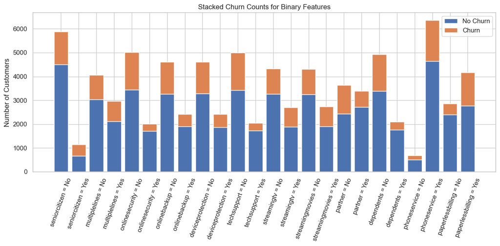

```python
plot_data = pd.DataFrame()

for col in binary_cols:
    counts = df.groupby([col, 'churn']).size().unstack(fill_value=0)
    counts['Feature'] = col
    counts['Value'] = counts.index
    plot_data = pd.concat([plot_data, counts.reset_index(drop=True)])

# Plot
fig, ax = plt.subplots(figsize=(12, 6))
plot_data['label'] = plot_data['Feature'] + ' = ' + plot_data['Value']

ax.bar(plot_data['label'], plot_data[0], label='No Churn')
ax.bar(plot_data['label'], plot_data[1], bottom=plot_data[0], label='Churn')

plt.xticks(rotation=70)
plt.ylabel('Number of Customers')
plt.title('Stacked Churn Counts for Binary Features')
plt.legend()
plt.tight_layout()
plt.show()
```

#### Binary Features and Their Relationship to Churn summary

The stacked bar plot and churn rate analysis provide a clear view of how various binary features relate to customer churn.

Key insights include:

- **Senior Citizen**
  - Churn rate is significantly higher for senior citizens (41.7%) compared to non-seniors (23.7%).
  - p-value < 0.0001 indicates this is statistically significant.
  - Suggests age-related factors may influence retention strategies.
- **Multiple Lines**
  - Customers with multiple phone lines show a slightly higher churn rate (28.6%) than those with a single line (25.1%).
  - While the effect is smaller, p-value = 0.0009 confirms it’s statistically meaningful.
- **Online Security, Backup, and Device Protection**
  - Customers without these services churn at much higher rates:
    - Online Security: 31.4% (No) vs. 14.6% (Yes)
    - Online Backup: 29.2% (No) vs. 21.6% (Yes)
    - Device Protection: 28.7% (No) vs. 22.5% (Yes)
  - All p-values < 0.0001.
  - These findings highlight the retention potential of bundled security features.
- **Tech Support**
  - A striking difference: churn is 31.2% without tech support vs. only 15.2% with it.
  - Reinforces the importance of accessible customer support.
- **Streaming Services (TV & Movies)**
  - Customers using streaming services tend to churn more:
    - TV: 30.1% (Yes) vs. 24.4% (No)
    - Movies: 29.9% (Yes) vs. 24.4% (No)
  - May indicate that entertainment services alone do not build loyalty.
- **Partner and Dependents**
  - Strong negative relationship with churn:
    - Partner: 33.0% (No) vs. 19.7% (Yes)
    - Dependents: 31.3% (No) vs. 15.5% (Yes)
  - Could suggest family commitments lead to more consistent service usage.
- **Phone Service**
  - Minimal difference in churn rate (26.7% vs. 25.0%), and p-value = 0.3499 indicates no significant impact.
- **Paperless Billing**
  - Customers using paperless billing churn far more (33.6%) than those who don’t (16.4%).
  - This may reflect broader behavioral trends, Emails get ignored (spam folder), Lack of physical reminders (accidental non-payment), or demographic trends—possibly more tech-savvy but less loyal users.

**Summary**

The analysis reveals that service features such as tech support, online security, and having a partner/dependents are protective against churn, while streaming services and paperless billing are positively associated with higher churn. These insights can inform targeted retention strategies, such as incentivizing tech support or bundling security features for high-risk segments.

**Recommended Actions:**

- Promote support services: Encourage adoption of tech support, online security, and device protection — these features are strongly linked to lower churn.
- Target senior citizens: Develop retention strategies tailored to older customers, who churn at significantly higher rates.
- Engage streaming users: Monitor and improve satisfaction among customers using streaming services, who show slightly higher churn.
- Review paperless billing strategy: Investigate why paperless billing users churn more — consider clearer communication or loyalty incentives.
- Leverage family-based stability: Prioritize marketing to or retaining customers with partners or dependents, as they are less likely to churn.
- Low-Priority: Phone service (phoneservice) has negligible impact → No intervention needed.

```python
# Drop irrelevant binary feature: phoneservice
df.drop('phoneservice', axis=1, inplace=True)
binary_cols = [col for col in binary_cols if col != 'phoneservice']
```

```
Churn Rates by contract:
contract
Month-to-month    0.427097
One year          0.112772
Two year          0.028487
Name: churn, dtype: float64
p-value: 0.0000

Churn Rates by paymentmethod:
paymentmethod
Electronic check             0.452854
Mailed check                 0.192020
Bank transfer (automatic)    0.167315
Credit card (automatic)      0.152531
Name: churn, dtype: float64
p-value: 0.0000

Churn Rates by internetservice:
internetservice
Fiber optic    0.418928
DSL            0.189983
No             0.074342
Name: churn, dtype: float64
p-value: 0.0000
```

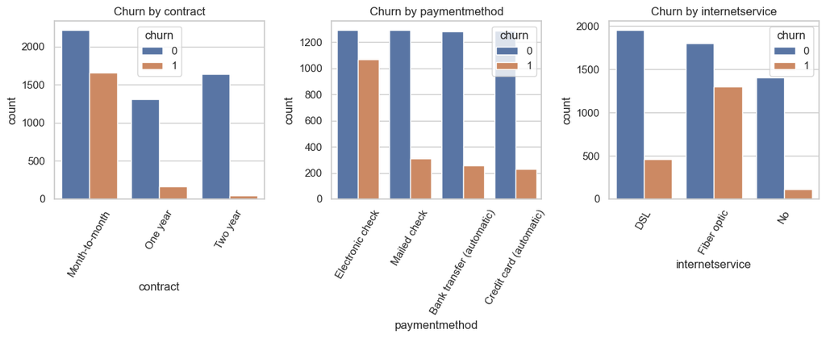

```python
# Non-binary Categorical Features vs churn
categorical = ['contract', 'paymentmethod', 'internetservice']

fig, axes = plt.subplots(1, 3, figsize=(4 * 3, 5))

for i, col in enumerate(categorical):
    sns.countplot(x=col, hue='churn', data=df, ax=axes[i])
    axes[i].set_title(f'Churn by {col}')
    axes[i].tick_params(axis='x', rotation=60)

    # Calculate churn rates
    print(f"\nChurn Rates by {col}:")
    print(df.groupby(col)['churn'].mean().sort_values(ascending=False))

    contingency_table = pd.crosstab(df[col], df['churn'])
    chi2, p_value, _, _ = chi2_contingency(contingency_table)
    print(f"p-value: {p_value:.4f}")

plt.tight_layout()
plt.show()
```

#### Non-binary categorical features summary

**1. Churn by Contract (The most critical factor)**

→ Customers dislike commitment → Consider incentives for longer contracts

- 1-year contracts show moderate churn (11.3%) → Good balance option

**2. Churn by Payment Method**

Electronic check users churn most (45.3%) → 3x higher than automatic payments( Automatic payments perform best at 15-17% churn)

→ Manual payment = higher friction → Strongly recommend auto-pay incentives

**3. Churn by Internet Service**

- Fiber optic shows paradoxically high churn (41.9%) despite being premium

→ Potential issues: pricing, reliability, or expectations mismatch

- DSL performs better (19% churn) → Fiber upgrade process may need review

**4. Churn by Phone Service**

- Phone service shows negligible difference (26.7% vs 25% churn)

→ Not a key churn driver → Can deprioritize in retention efforts

## Feature Selection

```python
from sklearn.preprocessing import OneHotEncoder

# Mapping all binary Yes/No to 0/1
for col in binary_cols:
    df[col] = df[col].map({'Yes': 1, 'No': 0})

# One-hot encode non-binary categoricals
categorical = ['contract', 'paymentmethod', 'internetservice']
df = pd.get_dummies(df, columns=categorical, drop_first=True).astype(int)
```

```python
from sklearn.model_selection import train_test_split

# train-test-split
X = df.drop('churn', axis=1)
y = df['churn']
X_train, X_test, y_train, y_test = train_test_split( X, y, test_size=0.2, random_state=42, stratify=y)
```

```python
from sklearn.feature_selection import chi2

X_train_cat = X_train.drop(columns=numerical)

# Run chi² test
chi2_scores, p_values = chi2(X_train_cat.values, y_train.values)

# Print results
for feat, chi2_stat, p_val in zip(
        X_train_cat.columns, chi2_scores, p_values):
    print(f"{feat}: χ² = {chi2_stat:.3f}, p = {p_val:.3f}")
```

```
seniorcitizen: χ² = 107.465, p = 0.000
partner: χ² = 68.835, p = 0.000
dependents: χ² = 115.449, p = 0.000
multiplelines: χ² = 6.293, p = 0.012
onlinesecurity: χ² = 123.177, p = 0.000
onlinebackup: χ² = 26.969, p = 0.000
deviceprotection: χ² = 15.095, p = 0.000
techsupport: χ² = 107.689, p = 0.000
streamingtv: χ² = 18.335, p = 0.000
streamingmovies: χ² = 14.799, p = 0.000
paperlessbilling: χ² = 80.883, p = 0.000
contract_One year: χ² = 153.476, p = 0.000
contract_Two year: χ² = 388.655, p = 0.000
paymentmethod_Credit card (automatic): χ² = 77.919, p = 0.000
paymentmethod_Electronic check: χ² = 346.644, p = 0.000
paymentmethod_Mailed check: χ² = 34.959, p = 0.000
internetservice_Fiber optic: χ² = 295.006, p = 0.000
internetservice_No: χ² = 228.447, p = 0.000
```

**Interpretation**

- multiplelines has χ² = 6.29 -> weak, and adds very little. Decision: drop
- onlinesecurity, onlinebackup, deviceprotection, techsupport all significant but somewhat overlapping (χ² from ~15 to ~125). They’re all “security/support” services. Rather than six separate binaries, we might capture overall “support package” strength. Decision: Create a single “num_support_services” = sum of those four flags.
- streamingtv, streamingmovies (χ² ~15–18), similar story: two highly related services with moderate signals. Decision: has_streaming = 1 if they subscribe to either
- Features like contract, paymentmethod, internetservice, seniorcitizen, partner, dependents, and paperlessbilling all showed strong χ². Decision: Keep those as separate dummies so your model can learn their distinct effects.

```python
# Dropping: multiplelines
df.drop('multiplelines', axis=1, inplace=True)

# Grouping 'onlinesecurity','onlinebackup','deviceprotection','techsupport' into a numerical variable
svc_cols = ['onlinesecurity','onlinebackup','deviceprotection','techsupport']
df['num_support_services'] = df[svc_cols].sum(axis=1)

# grouping streamingtv, streamingmovies
stream_cols = ['streamingtv', 'streamingmovies']
df['has_streaming'] = (df[stream_cols].sum(axis=1) > 0).astype(int)

# Dropping the original grouped variables
df = df.drop(columns=svc_cols)
df = df.drop(columns=stream_cols)
```

```python
# updating train-test-split
X = df.drop('churn', axis=1)
y = df['churn']
X_train, X_test, y_train, y_test = train_test_split( X, y, test_size=0.2, random_state=42, stratify=y)

# Updated Dataset
print("Dataset info:\n",df.info())
```

```
<class 'pandas.core.frame.DataFrame'>
Index: 7032 entries, 0 to 7042
Data columns (total 17 columns):
 #   Column                                 Non-Null Count  Dtype
---  ------                                 --------------  -----
 0   seniorcitizen                          7032 non-null   int64
 1   partner                                7032 non-null   int64
 2   dependents                             7032 non-null   int64
 3   tenure                                 7032 non-null   int64
 4   paperlessbilling                       7032 non-null   int64
 5   monthlycharges                         7032 non-null   int64
 6   totalcharges                           7032 non-null   int64
 7   churn                                  7032 non-null   int64
 8   contract_One year                      7032 non-null   int64
 9   contract_Two year                      7032 non-null   int64
 10  paymentmethod_Credit card (automatic)  7032 non-null   int64
 11  paymentmethod_Electronic check         7032 non-null   int64
 12  paymentmethod_Mailed check             7032 non-null   int64
 13  internetservice_Fiber optic            7032 non-null   int64
 14  internetservice_No                     7032 non-null   int64
 15  num_support_services                   7032 non-null   int64
 16  has_streaming                          7032 non-null   int64
dtypes: int64(17)
memory usage: 988.9 KB
Dataset info:
 None
```

```python
from sklearn.ensemble import RandomForestClassifier
from sklearn.metrics import classification_report

rf = RandomForestClassifier(class_weight='balanced', random_state=42)
rf.fit(X_train, y_train)

# Evaluate
y_pred = rf.predict(X_test)
print(classification_report(y_test, y_pred, digits=3))
```

```
              precision    recall  f1-score   support

           0      0.836     0.879     0.857      1033
           1      0.611     0.524     0.564       374

    accuracy                          0.785      1407
   macro avg      0.723     0.702     0.711      1407
weighted avg      0.776     0.785     0.779      1407
```

### Model Performance Summary (Random Forest Classifier):

- Accuracy: 78.5% — your model correctly predicted churn vs. no-churn in ~79% of cases overall.
- Class 0 (No Churn):
  - Precision: 83.6% — when the model predicts no churn, it's right most of the time.
  - Recall: 87.9% — it captures most of the actual no-churn cases.
- Class 1 (Churn):
  - Precision: 61.1% — when it predicts churn, it's correct ~61% of the time.
  - Recall: 52.4% — it's missing nearly half of actual churners (room to improve).
- F1-score for churn: 56.4% — this harmonic mean shows the model struggles more with predicting churn accurately than non-churn.

**Key Insight:** The model is still biased toward the majority class (no churn), which is expected in an imbalanced dataset.

## Model Improvement & Evaluation

```python
# SMOTE for class imbalance

from imblearn.over_sampling import SMOTE

# Applying SMOTE to training set only
smote = SMOTE(random_state=42)
X_train_resampled, y_train_resampled = smote.fit_resample(X_train, y_train)

# Checking class distribution after resampling
print("Before SMOTE:", y_train.value_counts())
print("After SMOTE:", y_train_resampled.value_counts())
```

```
Before SMOTE: churn
0    4130
1    1495
Name: count, dtype: int64
After SMOTE: churn
0    4130
1    4130
Name: count, dtype: int64
```

```python
# Train & Evaluate a Model After SMOTE

from sklearn.metrics import confusion_matrix

# Initialize and train the model
rf = RandomForestClassifier(random_state=42)
rf.fit(X_train_resampled, y_train_resampled)

# Predict on the original test set (never resample the test set)
y_pred = rf.predict(X_test)

# Evaluate
print("Confusion Matrix:")
print(confusion_matrix(y_test, y_pred))

print("\nClassification Report:")
print(classification_report(y_test, y_pred))
```

```
Confusion Matrix:
[[862 171]
 [145 229]]

Classification Report:
              precision    recall  f1-score   support

           0       0.86      0.83      0.85      1033
           1       0.57      0.61      0.59       374

    accuracy                           0.78      1407
   macro avg       0.71      0.72      0.72      1407
weighted avg       0.78      0.78      0.78      1407
```

**Interpretation**

- Recall (churn = 1) improved from ~0.52 → 0.61 after SMOTE. This is good, The model is now catching more actual churners.
- Precision (churn = 1) dropped slightly (expected). The model is flagging more churners, but some are false positives.
- Overall F1-score for class 1 improved. That’s the goal when handling imbalance, better recall without too much precision loss.
- Balanced performance: Still maintaining strong results for the majority class (No churn) and improving on the minority.

This result is a solid improvement, especially that the business objective is to detect churners more reliably, even at the cost of a few more false positives.

```python
# Trying other models

from sklearn.linear_model import LogisticRegression
from xgboost import XGBClassifier

# Logistic Regression
log_reg = LogisticRegression(max_iter=1000, class_weight=None, random_state=42)
log_reg.fit(X_train_resampled, y_train_resampled)
y_pred_log = log_reg.predict(X_test)

print("=== Logistic Regression ===")
print("Confusion Matrix:\n", confusion_matrix(y_test, y_pred_log))
print("\nClassification Report:\n", classification_report(y_test, y_pred_log))
```

```
=== Logistic Regression ===
Confusion Matrix:
 [[772 261]
 [103 271]]

Classification Report:
               precision    recall  f1-score   support

           0       0.88      0.75      0.81      1033
           1       0.51      0.72      0.60       374

    accuracy                           0.74      1407
   macro avg       0.70      0.74      0.70      1407
weighted avg       0.78      0.74      0.75      1407
```

```python
# XGBoost
xgb_model = XGBClassifier(use_label_encoder=False, eval_metric='logloss', random_state=42)
xgb_model.fit(X_train_resampled, y_train_resampled)
y_pred_xgb = xgb_model.predict(X_test)

print("\n=== XGBoost ===")
print("Confusion Matrix:\n", confusion_matrix(y_test, y_pred_xgb))
print("\nClassification Report:\n", classification_report(y_test, y_pred_xgb))
```

```
=== XGBoost ===
Confusion Matrix:
 [[827 206]
 [140 234]]

Classification Report:
               precision    recall  f1-score   support

           0       0.86      0.80      0.83      1033
           1       0.53      0.63      0.57       374

    accuracy                           0.75      1407
   macro avg       0.69      0.71      0.70      1407
weighted avg       0.77      0.75      0.76      1407
```

- Logistic Regression shows better recall for the minority class but slightly lower precision.
- XGBoost has slightly better precision but lower recall and F1 for class 1.

What this means:

- Both models improved recall compared to earlier (which is typical when using SMOTE).
- Logistic Regression is more "cautious", catching more positives but with more false positives.
- XGBoost is more "precise", fewer false positives but missing more true positives.

```python
# Testing models on original imbalanced data with class weights

# LogisticRegression
lr = LogisticRegression(class_weight='balanced', random_state=42, max_iter=1000)
lr.fit(X_train, y_train)
y_pred = lr.predict(X_test)

# Evaluate
print("=== Logistic Regression with class weights ===")
print(confusion_matrix(y_test, y_pred))
print(classification_report(y_test, y_pred))
```

```
=== Logistic Regression with class weights ===
[[714 319]
 [ 75 299]]
              precision    recall  f1-score   support

           0       0.90      0.69      0.78      1033
           1       0.48      0.80      0.60       374

    accuracy                           0.72      1407
   macro avg       0.69      0.75      0.69      1407
weighted avg       0.79      0.72      0.74      1407
```

```python
import xgboost as xgb

# Calculate scale_pos_weight
scale_pos_weight = sum(y_train == 0) / sum(y_train == 1)

xgb_model = xgb.XGBClassifier(scale_pos_weight=scale_pos_weight, use_label_encoder=False, eval_metric='logloss', random_state=42)
xgb_model.fit(X_train, y_train)
y_pred = xgb_model.predict(X_test)

# Evaluate
print("=== XGBoost with class weight ===")
print(confusion_matrix(y_test, y_pred))
print(classification_report(y_test, y_pred))
```

```
=== XGBoost with class weight ===
[[787 246]
 [113 261]]
              precision    recall  f1-score   support

           0       0.87      0.76      0.81      1033
           1       0.51      0.70      0.59       374

    accuracy                           0.74      1407
   macro avg       0.69      0.73      0.70      1407
weighted avg       0.78      0.74      0.76      1407
```

**Observations:**

- Logistic Regression:
  - Class weights increase recall (0.80 vs 0.72), meaning it catches more churners.
  - SMOTE gives slightly better precision and overall accuracy.
- XGBoost:
  - Class weights lead to better recall (0.70 vs 0.63) and slightly better f1-score.
  - SMOTE gives marginally higher precision and accuracy.

```python
# Logistic Regression tuning

from sklearn.model_selection import RandomizedSearchCV
from sklearn.metrics import make_scorer, f1_score, recall_score

# Defining Logistic Regression model
lr = LogisticRegression(class_weight='balanced', max_iter=1000, random_state=42)

# Define hyperparameter space
param_dist_lr = {'C': [0.01, 0.1, 1, 10, 100],
                 'penalty': ['l1', 'l2', 'elasticnet', 'none'],
                 'solver': ['saga'],
                 'l1_ratio': [0, 0.5, 1]}

# Create scorer
scorer = make_scorer(f1_score)  # or recall_score

# Setup RandomizedSearchCV
rs_lr = RandomizedSearchCV(lr, param_dist_lr, n_iter=20, scoring=scorer, cv=5, random_state=42, n_jobs=-1)

# Fit on resampled training data (X_train_resampled, y_train_resampled)
rs_lr.fit(X_train_resampled, y_train_resampled)

print("Best LR params:", rs_lr.best_params_)
print("Best LR score:", rs_lr.best_score_)
```

```
Best LR params: {'solver': 'saga', 'penalty': 'l1', 'l1_ratio': 0, 'C': 0.1}
Best LR score: 0.7514129533373989
```

Best LR params:

- Using 'solver': 'saga' with 'l1' penalty means Logistic Regression is doing feature selection (LASSO) while fitting.
- C=0.1 means stronger regularization (more penalty on complexity).
- l1_ratio=0 — likely no elastic net mixing (pure L1).

```python
# XGBoost Tuning

xgb = XGBClassifier(use_label_encoder=False, eval_metric='logloss', random_state=42)

param_dist_xgb = {'n_estimators': [50, 100, 200],
                  'max_depth': [3, 5, 7],
                  'learning_rate': [0.01, 0.1, 0.2],
                  'subsample': [0.6, 0.8, 1.0],
                  'colsample_bytree': [0.6, 0.8, 1.0],
                  'scale_pos_weight': [1, y_train.value_counts()[0]/y_train.value_counts()[1]]}

rs_xgb = RandomizedSearchCV(xgb, param_dist_xgb, n_iter=20, scoring=scorer, cv=5, random_state=42, n_jobs=-1)

rs_xgb.fit(X_train_resampled, y_train_resampled)

print("Best XGB params:", rs_xgb.best_params_)
print("Best XGB score:", rs_xgb.best_score_)
```

```
Best XGB params: {'subsample': 0.6, 'scale_pos_weight': np.float64(2.762541806020067), 'n_estimators': 200, 'max_depth': 7, 'learning_rate': 0.1, 'colsample_bytree': 1.0}
Best XGB score: 0.8310547862333133
```

**Best XGB params:**

- subsample=0.6: uses 60% of data per tree, adding randomness to reduce overfitting.
- scale_pos_weight=2.76: compensates for class imbalance, telling XGB to weigh positives more.
- n_estimators=200, max_depth=7, learning_rate=0.1, colsample_bytree=1.0: fairly typical boosting parameters with a balanced complexity.

```python
# Evaluate best tuned models on test data

# Logistic Regression
best_lr = rs_lr.best_estimator_
y_pred_lr = best_lr.predict(X_test)
print("Logistic Regression Classification Report:\n", classification_report(y_test, y_pred_lr))

# XGBoost
best_xgb = rs_xgb.best_estimator_
y_pred_xgb = best_xgb.predict(X_test)
print("XGBoost Classification Report:\n", classification_report(y_test, y_pred_xgb))
```

```
Logistic Regression Classification Report:
               precision    recall  f1-score   support

           0       0.90      0.67      0.77      1033
           1       0.46      0.80      0.59       374

    accuracy                           0.70      1407
   macro avg       0.68      0.73      0.68      1407
weighted avg       0.79      0.70      0.72      1407

XGBoost Classification Report:
               precision    recall  f1-score   support

           0       0.89      0.73      0.80      1033
           1       0.50      0.75      0.60       374

    accuracy                           0.73      1407
   macro avg       0.69      0.74      0.70      1407
weighted avg       0.78      0.73      0.75      1407
```

#### Interpretation of Results

- Logistic Regression has slightly better recall on churners (class 1), meaning it catches more at-risk customers but with lower precision (more false positives).
- XGBoost balances precision and recall a bit better, with a slightly higher F1 and overall accuracy.
- Both models have decent recall (~75-80%), which is key for your goal to identify churners.
- XGBoost seems stronger overall

## Finalizing the Model

```python
# Best hyperparameters from tuning
best_params = {'subsample': 0.6,
               'scale_pos_weight': 2.76,
               'n_estimators': 200,
               'max_depth': 7,
               'learning_rate': 0.1,
               'colsample_bytree': 1.0,
               'use_label_encoder': False,
               'eval_metric': 'logloss'}

# Initialize model with best params
final_model = XGBClassifier(**best_params)

# Fitting on the full training data
final_model.fit(X_train_resampled, y_train_resampled)
```

```
XGBClassifier(base_score=None, booster=None, callbacks=None,
              colsample_bylevel=None, colsample_bynode=None,
              colsample_bytree=1.0, device=None, early_stopping_rounds=None,
              enable_categorical=False, eval_metric='logloss',
              feature_types=None, feature_weights=None, gamma=None,
              grow_policy=None, importance_type=None,
              interaction_constraints=None, learning_rate=0.1, max_bin=None,
              max_cat_threshold=None, max_cat_to_onehot=None,
              max_delta_step=None, max_depth=7, max_leaves=None,
              min_child_weight=None, missing=nan, monotone_constraints=None,
              multi_strategy=None, n_estimators=200, n_jobs=None,
              num_parallel_tree=None, ...)
```

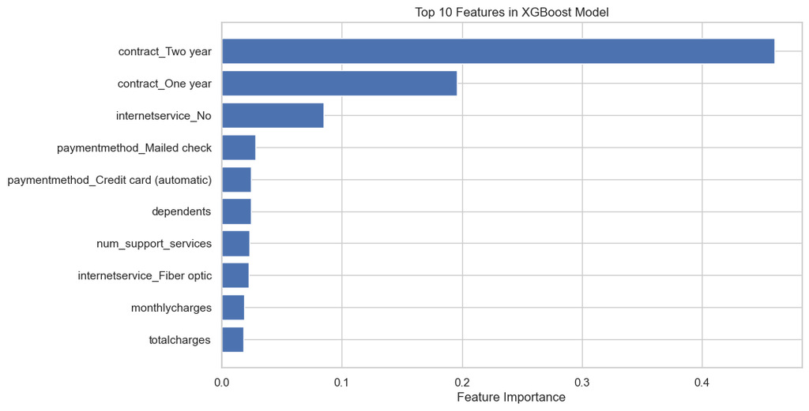

```python
# Get feature importances
importances = final_model.feature_importances_
features = X_train_resampled.columns

# Put into a DataFrame (for easy viewing)
feat_imp_df = pd.DataFrame({'feature': features, 'importance': importances}).sort_values(by='importance', ascending=False)

# Plot top 10 features
plt.figure(figsize=(10,6))
plt.barh(feat_imp_df['feature'][:10][::-1], feat_imp_df['importance'][:10][::-1])
plt.xlabel('Feature Importance')
plt.title('Top 10 Features in XGBoost Model')
plt.show()
```

**Top 10 Important Features in the XGBoost Churn Model**

The bar chart above shows the top 10 most influential features in the XGBoost model based on feature importance (gain-based), which measures how useful each feature is in improving decision trees during model training.

**Key Takeaways:**

- **Contract Type (contract_Two year, contract_One year)**
  - The contract length is by far the most influential predictor of churn.
  - Customers with long-term contracts are significantly less likely to churn.
- **Internet Service Type (internetservice_No)**
  - Customers without internet service (likely non-tech-heavy users) are less prone to churn, possibly because they use fewer services or have different expectations.
- **Payment Methods (paymentmethod_Mailed check, paymentmethod_Credit card (automatic))**
  - The method of payment influences churn. Automatic payments (e.g., credit cards) correlate with better retention compared to mailed checks.
- **Dependents**
  - Customers with dependents show lower churn, suggesting they may value stability and bundled services more.
- **Number of Support Services (num_support_services)**
  - Using more additional services (e.g., online backup, tech support) decreases churn, likely due to increased engagement and perceived value.
- **Internet Type - Fiber Optic (internetservice_Fiber optic)**
  - Surprisingly, fiber optic users are more likely to churn — possibly due to price sensitivity or service issues.
- **Monthly Charges and Total Charges**
  - Customers paying higher monthly charges tend to churn more, while total charges are less influential, perhaps due to their correlation with tenure.

**Implications:**

- Promote long-term contracts to boost retention.
- Investigate churn reasons among fiber optic users.
- Encourage engagement with support and additional services.
- Facilitate easy and automated payment methods.
- Target high-monthly-charge users with loyalty programs or tailored offers.

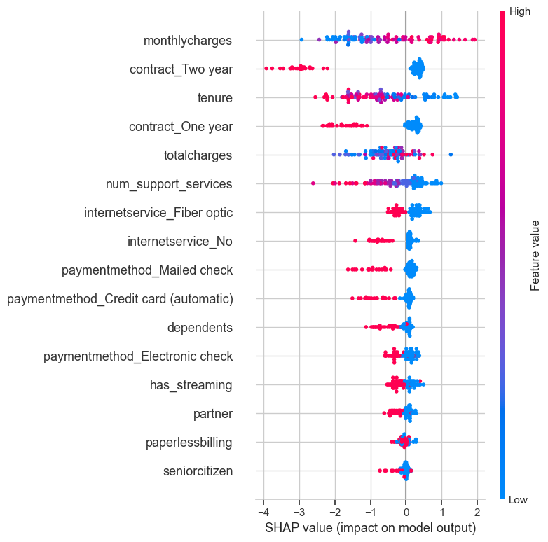

```python
import shap

# Initialize the explainer using the trained model
explainer = shap.TreeExplainer(final_model)

# Use a sample of X_train (or X_test) to calculate SHAP values
# Use the same X_test that was used for evaluation
X_sample = X_test.sample(100, random_state=42)  # Use a manageable sample size

# Calculate SHAP values
shap_values = explainer.shap_values(X_sample)

# Summary plot
shap.summary_plot(shap_values, X_sample)
```

## Model Explainability with SHAP

To understand the inner workings of our final XGBoost churn prediction model, we applied SHAP (SHapley Additive exPlanations), a powerful interpretability method that attributes prediction outcomes to individual feature contributions.

[output not shown]

##### Business Implications:

- **Reduce Monthly Charges:** Consider discounts or bundling for high-charge plans.
- **Promote Long-Term Contracts:** Incentivize one- and two-year contracts to retain customers.
- **Onboard New Users Better:** Offer support and incentives early in a customer’s lifecycle to increase tenure.
- **Evaluate Fiber Optic Service:** Investigate potential issues driving dissatisfaction.
- **Simplify Payments:** Encourage more stable or automated payment methods over electronic checks.
- **Encourage Service Engagement:** Promote value-added services like online security and backups.